# Phase2

vineet

October 22, 2018

## R Markdown

@ authors: Vineet Vats (vxv180008) and Shruti Jaiswal (sxj170027)  
The Ethereum project is a blockchain platform, and our data comes from there. Although Ethereum started in 2015, most tokens have been created since 2016. As such, tokens have different starting dates, and their data starts from that initial date. Our Data has four Attributes: FromNodeId - Selling the Token,  
ToNodeId- Buying the Token,  
Unixdate- Data of transaction in UNIX time,  
TokenAmount- Token amount in the Transaction,  
The second dataset has attributes:  
Date  
Open  
High  
Low  
Close  
Volume  
MarketCap

Reading the zrx Token Data and removing the outliers from the data zrxtoken.

```r
library(tidyverse)
library(sqldf)
zrxtoken<-read.table(file="D:/networkzrxTX.txt",header=F,sep=" ")
zrxtoken <- zrxtoken[ which(zrxtoken$V4<=1e+27), ]
colnames(zrxtoken)<-c("FromNodeId","ToNodeId","Unixdate","TokenAmount")
summary(zrxtoken)
```

```
##    FromNodeId         ToNodeId          Unixdate
##  Min.   :      4   Min.   :      2   Min.   :1.502e+09
##  1st Qu.:  44146   1st Qu.: 104233   1st Qu.:1.506e+09
##  Median :1746888   Median :1759326   Median :1.515e+09
##  Mean   :2523044   Mean   :3406836   Mean   :1.513e+09
##  3rd Qu.:2777146   3rd Qu.:5919106   3rd Qu.:1.519e+09
##  Max.   :9982269   Max.   :9982274   Max.   :1.526e+09
##   TokenAmount
##  Min.   :1.000e+00
##  1st Qu.:3.060e+20
##  Median :1.994e+21
##  Mean   :2.430e+22
##  3rd Qu.:8.000e+21
##  Max.   :5.199e+26
```

```r
options(max.print = 20)
```

Converting the date from Unix time format to Date format.

```r
zrxtoken$Unixdate<- as.Date(as.POSIXct(zrxtoken$Unixdate, origin="1970-01-01"))
zrxtoken$Unixdate
```

```
##  [1] "2018-04-24" "2018-04-24" "2018-04-24" "2018-04-24" "2018-04-24"
##  [6] "2018-04-24" "2018-04-24" "2018-04-24" "2018-04-24" "2018-04-24"
## [11] "2018-04-24" "2018-04-24" "2018-04-24" "2018-04-24" "2018-04-24"
## [16] "2018-04-24" "2018-04-24" "2018-04-24" "2018-04-24" "2018-04-24"
##  [ reached getOption("max.print") -- omitted 295367 entries ]
```

Dividing the data into 25 disjoint layers. This is first part of dividing the data into layers and finding insights out of the data.

```r
layer1<- zrxtoken[which(zrxtoken$TokenAmount>1e+24),]
layer2<- zrxtoken[which(zrxtoken$TokenAmount<=1e+24 & zrxtoken$TokenAmount>1e+23),]
layer3<- zrxtoken[which(zrxtoken$TokenAmount<=1e+23 & zrxtoken$TokenAmount>1e+22),]
layer4<- zrxtoken[which(zrxtoken$TokenAmount<=1e+22 & zrxtoken$TokenAmount>1e+21),]
layer5<- zrxtoken[which(zrxtoken$TokenAmount<=1e+21 & zrxtoken$TokenAmount>1e+20),]
layer6<- zrxtoken[which(zrxtoken$TokenAmount<=1e+20 & zrxtoken$TokenAmount>1e+19),]
layer7<- zrxtoken[which(zrxtoken$TokenAmount<=1e+19 & zrxtoken$TokenAmount>1e+18),]
laye8<- zrxtoken[which(zrxtoken$TokenAmount<=1e+18 & zrxtoken$TokenAmount>1e+17),]
layer9<- zrxtoken[which(zrxtoken$TokenAmount<=1e+17 & zrxtoken$TokenAmount>1e+16),]
layer10<- zrxtoken[which(zrxtoken$TokenAmount<=1e+16 & zrxtoken$TokenAmount>1e+15),]
layer11<- zrxtoken[which(zrxtoken$TokenAmount<=1e+15 & zrxtoken$TokenAmount>1e+14),]
layer12<- zrxtoken[which(zrxtoken$TokenAmount<=1e+14 & zrxtoken$TokenAmount>1e+13),]
layer13<- zrxtoken[which(zrxtoken$TokenAmount<=1e+13 & zrxtoken$TokenAmount>1e+12),]
layer14<- zrxtoken[which(zrxtoken$TokenAmount<=1e+12 & zrxtoken$TokenAmount>1e+11),]
layer15<- zrxtoken[which(zrxtoken$TokenAmount<=1e+11 & zrxtoken$TokenAmount>1e+10),]
layer16<- zrxtoken[which(zrxtoken$TokenAmount<=1e+10 & zrxtoken$TokenAmount>1e+9),]
layer17<- zrxtoken[which(zrxtoken$TokenAmount<=1e+9 & zrxtoken$TokenAmount>1e+8),]
layer18<- zrxtoken[which(zrxtoken$TokenAmount<=1e8 & zrxtoken$TokenAmount>1e+7),]
layer19<- zrxtoken[which(zrxtoken$TokenAmount<=1e+7 & zrxtoken$TokenAmount>1e+6),]
layer20<- zrxtoken[which(zrxtoken$TokenAmount<=1e+6 & zrxtoken$TokenAmount>1e+5),]
layer21<- zrxtoken[which(zrxtoken$TokenAmount<=1e+5 & zrxtoken$TokenAmount>1e+4),]
layer22<- zrxtoken[which(zrxtoken$TokenAmount<=1e+4 & zrxtoken$TokenAmount>1e+3),]
layer23<- zrxtoken[which(zrxtoken$TokenAmount<=1e+3 & zrxtoken$TokenAmount>1e+2),]
layer24<- zrxtoken[which(zrxtoken$TokenAmount<=1e+2 & zrxtoken$TokenAmount>1e+1),]
layer25<- zrxtoken[which(zrxtoken$TokenAmount<1e+1),]
```

Merging Layers so that the number of observations present in each layer is comparable.(I have done this based on correlation factor which will come later in the report.)

```r
layer1<- zrxtoken[which(zrxtoken$TokenAmount>1e+22),]
layer2<- zrxtoken[which(zrxtoken$TokenAmount<=1e+22 & zrxtoken$TokenAmount>1e+21),]
layer3<- zrxtoken[which(zrxtoken$TokenAmount<=1e+21 & zrxtoken$TokenAmount>1e+20),]

layer4<- zrxtoken[which(zrxtoken$TokenAmount<=1e+20 & zrxtoken$TokenAmount>1e+19),]
layer5<- zrxtoken[which(zrxtoken$TokenAmount<=1e+19 & zrxtoken$TokenAmount>1e+15),]
layer6<- zrxtoken[which(zrxtoken$TokenAmount<=1e+15 & zrxtoken$TokenAmount>1e+5),]
layer7<- zrxtoken[which(zrxtoken$TokenAmount<=1e+5),]
```

```r
Flayer_1 <-c(layer4[,3])
summary(Flayer_1)
```

```
##         Min.      1st Qu.       Median         Mean      3rd Qu.
## "2017-08-15" "2017-11-15" "2018-01-23" "2018-01-07" "2018-02-27"
##         Max.
## "2018-05-06"
```

```r
count_layer1<-as.data.frame(table(Flayer_1))
colnames(count_layer1)<-c("Date","Frequency")
count_layer1$Date<- as.Date(as.POSIXct(count_layer1$Date, origin="1970-01-01"))
summary(count_layer1)
```

```
##       Date              Frequency
##  Min.   :2017-08-15   Min.   : 15.0
##  1st Qu.:2017-10-20   1st Qu.: 52.0
##  Median :2017-12-25   Median : 83.0
##  Mean   :2017-12-25   Mean   :117.1
##  3rd Qu.:2018-03-01   3rd Qu.:135.0
##  Max.   :2018-05-06   Max.   :636.0
```

Here in this step we are reading the Token prices data.

```r
pricezrx<-read.table(file="D:/zrx.txt",header=F,sep="\t")
colnames(pricezrx)<-c("Date","Open","High","Low","Close","Volume","MarketCap")
summary(pricezrx)
```

```
##         Date          Open             High             Low
##  1/1/2018 :  1   Min.   :0.1117   Min.   :0.1764   Min.   :0.1040
##  1/10/2018:  1   1st Qu.:0.2281   1st Qu.:0.2387   1st Qu.:0.2121
##      Close              Volume            MarketCap
##  Min.   :0.1708   1,000,210:  1   1,008,110,000:  1
##  1st Qu.:0.2289   1,091,020:  1   1,017,560,000:  1
##  [ reached getOption("max.print") -- omitted 5 rows ]
```

Selecting Date and Opening price from the tokenprices dataset and converting the date to the same format as in zrxToken.

```r
pricezrx<-pricezrx[c(1,2)]
pricezrx$Date<-as.Date(pricezrx$Date,format="%m/%d/%Y")
pricezrx$Date<- as.Date(as.POSIXct(pricezrx$Date, origin="1970-01-01"))
summary(pricezrx)
```

```
##       Date                 Open
##  Min.   :2017-08-16   Min.   :0.1117
##  1st Qu.:2017-11-04   1st Qu.:0.2281
##  Median :2018-01-24   Median :0.6347
##  Mean   :2018-01-24   Mean   :0.7474
##  3rd Qu.:2018-04-14   3rd Qu.:1.1050
##  Max.   :2018-07-04   Max.   :2.3700
```

SQL commands join Zrx Token Data and Zrx prices data based on the Date which is present in both the Datasets.

```r
df3<-sqldf("SELECT f.Date, p.Open, f.Frequency FROM count_layer1 f INNER JOIN pricezrx p WHERE f.Date=p.Date")
summary(df3)
```

```
##       Date                 Open          Frequency
##  Min.   :2017-08-16   Min.   :0.1117   Min.   : 15.0
##  1st Qu.:2017-10-20   1st Qu.:0.2145   1st Qu.: 52.0
##  Median :2017-12-25   Median :0.5086   Median : 83.5
##  Mean   :2017-12-25   Mean   :0.6550   Mean   :117.3
##  3rd Qu.:2018-03-01   3rd Qu.:0.9687   3rd Qu.:135.0
##  Max.   :2018-05-06   Max.   :2.3700   Max.   :636.0
```

Applying Pearson Correlation on the data.

```r
cor.test(df3$Open, df3$Frequency, method = "pearson")
```

```
##
##  Pearson's product-moment correlation
##
## data:  df3$Open and df3$Frequency
## t = 15.645, df = 262, p-value < 2.2e-16
## alternative hypothesis: true correlation is not equal to 0
## 95 percent confidence interval:
##  0.6268344 0.7525555
## sample estimates:
##       cor
## 0.6949691
```

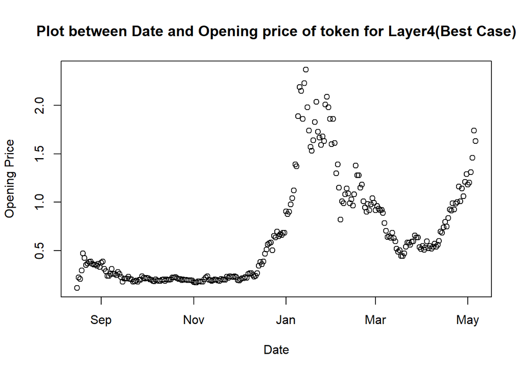

```r
plot(df3$Date,df3$Open, main= "Plot between Date and Opening price of token for Layer4(Best Case)", xlab="Date", ylab="Opening Price")
```

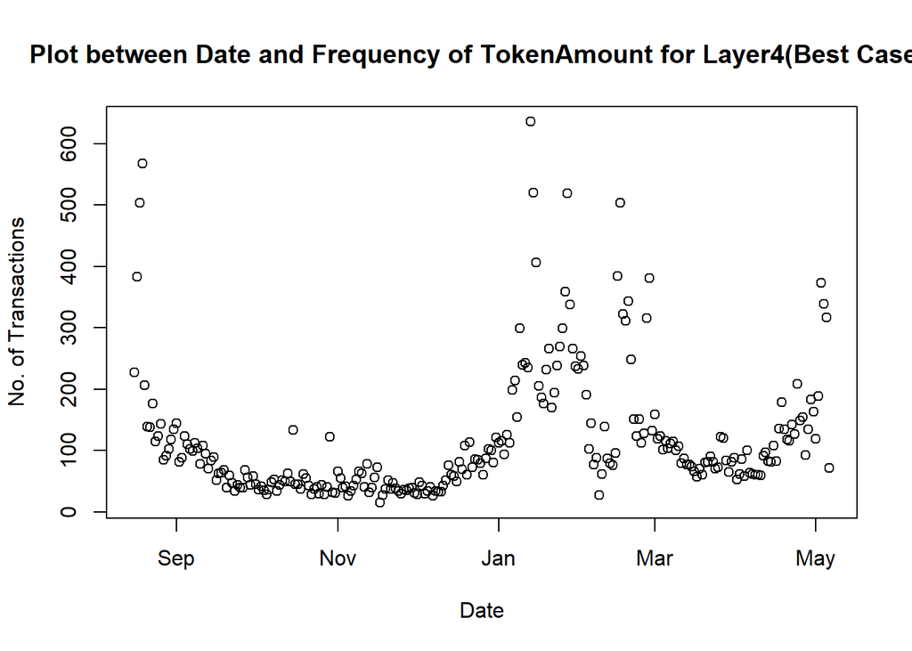

```r
plot(df3$Date,df3$Frequency, main= "Plot between Date and Frequency of TokenAmount for Layer4(Best Case) ", xlab="Date", ylab="No. of Transactions")
```

Scatterplot of Open Price Versus No. of Transactions using Pearson Correlation

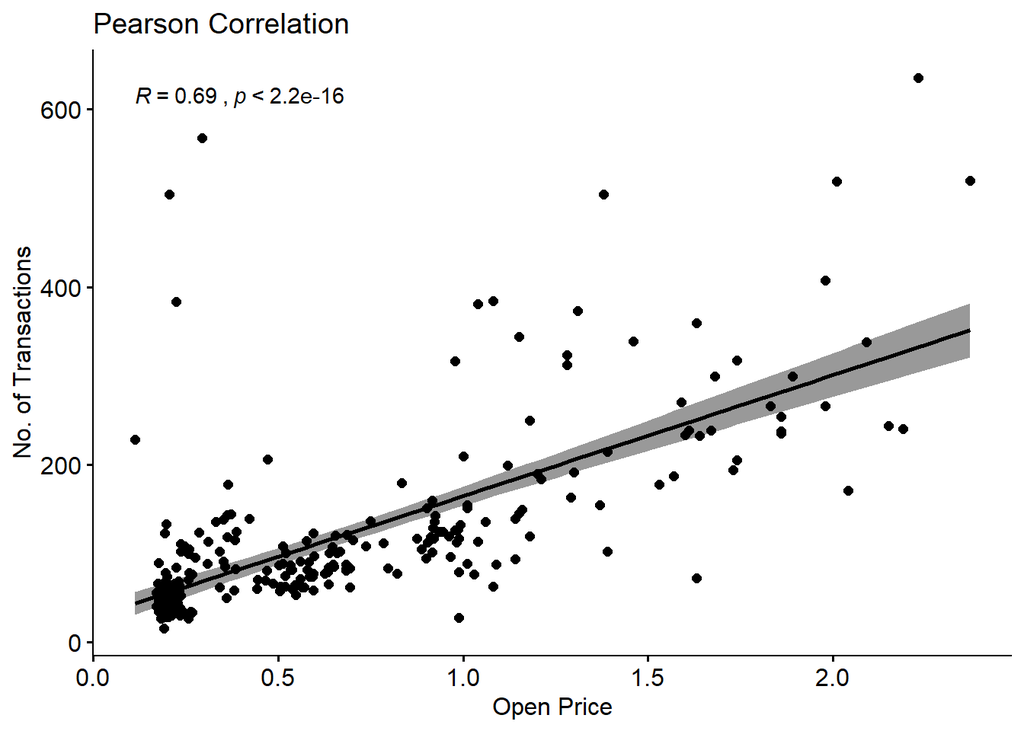

```r
library("ggpubr")
ggscatter(df3, x = "Open", y = "Frequency",
          add = "reg.line", conf.int = TRUE,
          cor.coef = TRUE, cor.method = "pearson",
          xlab = "Open Price", ylab = "No. of Transactions", main="Pearson Correlation")
```

Applying Spearman Correlation on the data and generating scatterplot of Open Price Versus No. of Transactions using Spearman Correlation

```r
cor.test(df3$Open, df3$Frequency, method = "spearman")
```

```
##
##  Spearman's rank correlation rho
##
## data:  df3$Open and df3$Frequency
## S = 702780, p-value < 2.2e-16
## alternative hypothesis: true rho is not equal to 0
## sample estimates:
##       rho
## 0.7708249
```

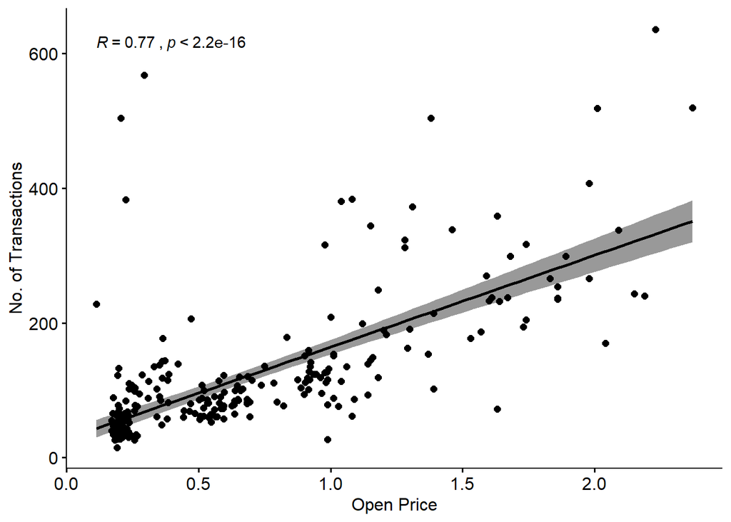

```r
ggscatter(df3, x = "Open", y = "Frequency",
          add = "reg.line", conf.int = TRUE,
          cor.coef = TRUE, cor.method = "spearman",
          xlab = "Open Price", ylab = "No. of Transactions")
```

To show the difference between a correlated layer and non correlated layer here we have also plotted worst case when pearson correlation factor is very close to zero.

```r
Flayer_1 <-c(layer6[,3])
#summary(Flayer_1)
count_layer1<-as.data.frame(table(Flayer_1))
#View(count_layer1)
colnames(count_layer1)<-c("Date","Frequency")
count_layer1$Date<- as.Date(as.POSIXct(count_layer1$Date, origin="1970-01-01"))
#summary(count_layer1)

pricetenx<-read.table(file="D:/zrx.txt",header=F,sep="\t")
colnames(pricetenx)<-c("Date","Open","High","Low","Close","Volume","MarketCap")
#summary(pricetenx)

pricetenx<-pricetenx[c(1,2)]
pricetenx$Date<-as.Date(pricetenx$Date,format="%m/%d/%Y")
pricetenx$Date<- as.Date(as.POSIXct(pricetenx$Date, origin="1970-01-01"))
#summary(pricetenx)

df3<-sqldf("SELECT f.Date, p.Open, f.Frequency FROM count_layer1 f INNER JOIN pricetenx p WHERE f.Date=p.Date")
#summary(df3)

cor.test(df3$Open, df3$Frequency, method = "pearson")
```

```
##
##  Pearson's product-moment correlation
##
## data:  df3$Open and df3$Frequency
## t = -0.82806, df = 115, p-value = 0.4094
## alternative hypothesis: true correlation is not equal to 0
## 95 percent confidence interval:
##  -0.2549577  0.1060269
## sample estimates:
##         cor
## -0.07698794
```

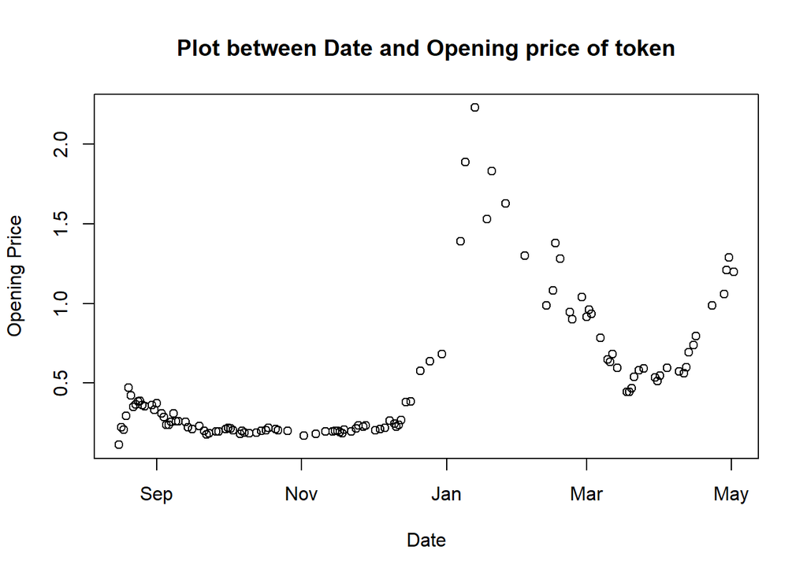

```r
plot(df3$Date,df3$Open, main= "Plot between Date and Opening price of token", xlab="Date", ylab="Opening Price")
```

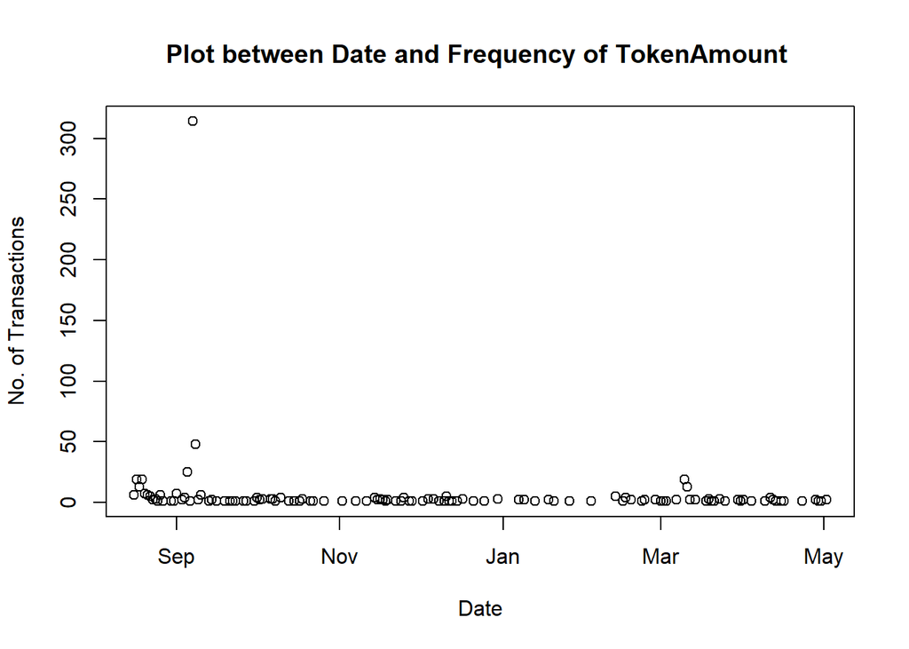

```r
plot(df3$Date,df3$Frequency, main= "Plot between Date and Frequency of TokenAmount ", xlab="Date", ylab="No. of Transactions")
```

Hence, In this Question firstly We divided the layers into 25 equal parts and then to make the observations comparable with each other, we have merged the layers into 7 different sized layers. We found that observations having token amount in range 1e+19 and 1e+20 are correlating the most with the opening price of the token. The second observation is that the Pearson’s Correlation coefficient is 0.70 and the Spearman’s Correlation coefficient is o.77.